# podesta_email_dataset_processing_and_analysis

### Community Detection

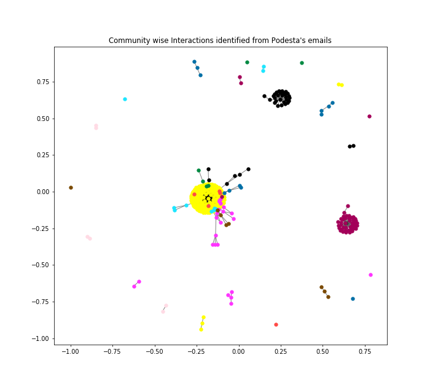

```python
#!pip install python-louvain
nxgraph_test = nx.from_pandas_edgelist(all_interact, source='from_email',
                                  target='to_email', edge_attr='conv_date',
                                  create_using = nx.Graph())
plt.figure(figsize=(10,9))
partition = cm.best_partition(nxgraph_test)
pos=nx.spring_layout(nxgraph_test)
for com in set(partition.values()):
    list_nodes = [nodes for nodes in partition.keys() if partition[nodes]==com]
    nx.draw_networkx_nodes(nxgraph_test, pos, list_nodes, edge_color = '#babab8',node_size=30,
                           node_color=colors[com%10])
plt.title("Community wise Interactions identified from Podesta's emails")
nx.draw_networkx_edges(nxgraph_test, pos, alpha=0.5)
plt.show()
```

**Notes:**

- email addresses need to be cleaned and entries with multiple addresses need to be split and cleaned with separate row added for each address (i.e.) there should be a single address for one to one interaction
- Email addresses should be minimized and unwanted addresses should be removed

```python
pod_net['ext_date'] = pod_net['conv_date'].apply(lambda x: parse(x).strftime('%Y-%m-%d'))
pod_net['ext_m_y'] = pod_net['conv_date'].apply(lambda x: parse(x).strftime('%m-%y'))
pod_net['ext_w_day'] = pod_net['conv_date'].apply(lambda x: parse(x).strftime('%a'))
pod_net['ext_hour'] = pod_net['conv_date'].apply(lambda x: parse(x).strftime('%H'))
pod_net['ext_month'] = pod_net['conv_date'].apply(lambda x: parse(x).strftime('%b'))
```

```python
pod_date = pod_net.groupby(['ext_date','ext_w_day', 'ext_m_y','ext_hour','ext_month'])['from_name'].count().reset_index()

pod_wrd = pod_net.groupby(['ext_date'])['total_len'].mean().reset_index()
```

```python
pod_date.head(2)
```

|  | ext_date | ext_w_day | ext_m_y | ext_hour | ext_month | from_name |
| --- | --- | --- | --- | --- | --- | --- |
| 0 | 2000-06-29 | Thu | 06-00 | 20 | Jun | 1 |
| 1 | 2004-06-17 | Thu | 06-04 | 16 | Jun | 1 |

```python
plot1 = go.Scatter(x=pod_date['ext_date'], y=pod_date['from_name'], mode='lines', name= 'date')
plot2 = go.Bar(x=pod_date['ext_m_y'], y=pod_date['from_name'], name= 'month_yr')
plot3 = go.Bar(x=pod_date['ext_w_day'], y=pod_date['from_name'], name= 'weekday')
plot4 = go.Bar(x=pod_date['ext_hour'], y=pod_date['from_name'], name= 'hour')
plot5 = go.Bar(x=pod_date['ext_month'], y=pod_date['from_name'], name= 'month')

fig = tools.make_subplots(rows=3, cols=2, subplot_titles=('by date', 'month-year',
                                                        'weekday', 'by_hour', 'by_month'))

fig.append_trace(plot1, 1, 1)
fig.append_trace(plot2, 1, 2)
fig.append_trace(plot3, 2, 1)
fig.append_trace(plot4, 2, 2)
fig.append_trace(plot5, 3, 1)

fig['layout'].update(height=1000, width=900, title='Average # of emails received by datetime')

iplot(fig, show_link=False)

#aggregations need to be included to display proper numbers when cursor is hovered
```

```
This is the format of your plot grid:
[ (1,1) x1,y1 ]  [ (1,2) x2,y2 ]
[ (2,1) x3,y3 ]  [ (2,2) x4,y4 ]
[ (3,1) x5,y5 ]  [ (3,2) x6,y6 ]
```

[interactive chart not shown]

**Possible Insights from above plot (plots need to be fixed):**

- there seem to be higher amount of email received during the years 2008, 2014 and 2015, which could be for campaign reasons
- there doesnt seem to be variations in the number of emails received in weekdays or months
- The number of emails seem to reduce after midnight and increase after 8:00 AM within a day

```python
iplot(go.Figure([go.Bar(x= pod_wrd['ext_date'], y=pod_wrd['total_len'])], go.Layout(title="Average words per email by date")), show_link=False)
```

[interactive chart not shown]

```python
#exclude emails from advertisers / mailinglists etc
podesta_subset.head()
sent='this is a test string'
podesta_subset['list_body'] = podesta_subset['stprem_body'].apply(lambda x: [f for f in x.split()])
cons_word_list = list(itertools.chain.from_iterable([a for a in podesta_subset['list_body']]))
words_mail = ' '.join(str(i) for i in cons_word_list)
```

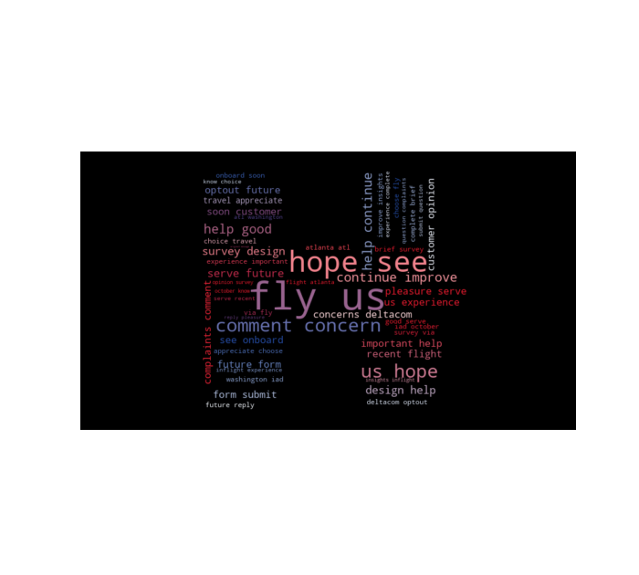

```python
#!pip install wordcloud
#added hillary's campamign logo to teh word cloud
import numpy as np
from PIL import Image
logo_mask = np.array(Image.open(cwd+r'/img/hc_logo.jpg'))
stopwords = set(STOPWORDS)
stopwords.update(['dear', 'email', 'contact', 'john', 'please', 'share',
                  'link', 'receive','send','sent', 'click', 'call', 'follow',
                 'thank', 'thank you', 'response', 'comments', 'feedback',
                  'mailings', 'autogenerated'])
plt.figure(figsize=(10,9))
wcloud = WordCloud(stopwords=stopwords, mode='RGBA', mask=logo_mask,
                   background_color='black', normalize_plurals=True,
                  repeat=False).generate(str(words_mail))
image_colors = ImageColorGenerator(logo_mask)
plt.imshow(wcloud.recolor(color_func=image_colors), interpolation='bilinear')
plt.axis("off")
plt.show()
```

## Analysing Text from the emails

**Refer:**

- [Text analytics methods](https://www.analyticsvidhya.com/blog/2018/02/the-different-methods-deal-text-data-predictive-python/)
- [Information on topic modelling using LDA](https://towardsdatascience.com/topic-modeling-and-latent-dirichlet-allocation-in-python-9bf156893c24)

```python
print(time.time()-ovst)

# 40 mins to run entire notebook
```

```
258.4403259754181
```

```python
del plot1
del plot2
del plot3
del plot4
del plot5
del ovst
del nxgraph
del mail_podesta
del words_mail
del top20_interact
del wcloud
del nxgraph_20
del pod_net
del podesta_df
del sent

% who
```

[output not shown]

```python
!jupyter nbconvert --to html podesta_email_dataset_processing_and_analysis.ipynb
os.rename('podesta_email_dataset_processing_and_analysis.html', 'index.html')
```

```
[NbConvertApp] Converting notebook podesta_email_dataset_processing_and_analysis.ipynb to html
[NbConvertApp] Writing 3305685 bytes to podesta_email_dataset_processing_and_analysis.html
```

###### [Avinash Pasupulate - Linkedin Profile](https://www.linkedin.com/in/avinashpasupulate/)